# Untitled

James D Santos

2023-10-03

## R Markdown

Vimos anteriormente que uma onda, de período $p$, pode ser representada pela função harmônica

$$g_1(t)=A_1\cos\left(\frac{2\pi}{p}t+\phi_1\right).$$
Acontece que é possível que existam outros ciclos dentro do de duração $p$.

$$g_2(t)=A_2\cos\left(\frac{2\pi}{6}t+\phi_2\right)$$

Também podemos ter um ciclo se repetindo a cada quatrimestre

$$g_3(t)=A_3\cos\left(\frac{2\pi}{4}t+\phi_3\right),$$
e outro a cada trimestre

$$g_4(t)=A_4\cos\left(\frac{2\pi}{3}t+\phi_4\right).$$

Então, o nosso padrão sazonal seria a soma desses harmônicos:

$$g(t)=\sum_{j=1}^4 g_{j}(t)=\sum_{j=1}^4
A_j\cos\left(\frac{2\pi}{p}jt+\phi_j\right).$$
A função $g_j(t)$ é denominada $j$-ésimo harmônico e é possível ter $q$ harmônicos, onde $q$ é a parte inteira de $p/2$.

A figura abaixo ilustra essa ideia.

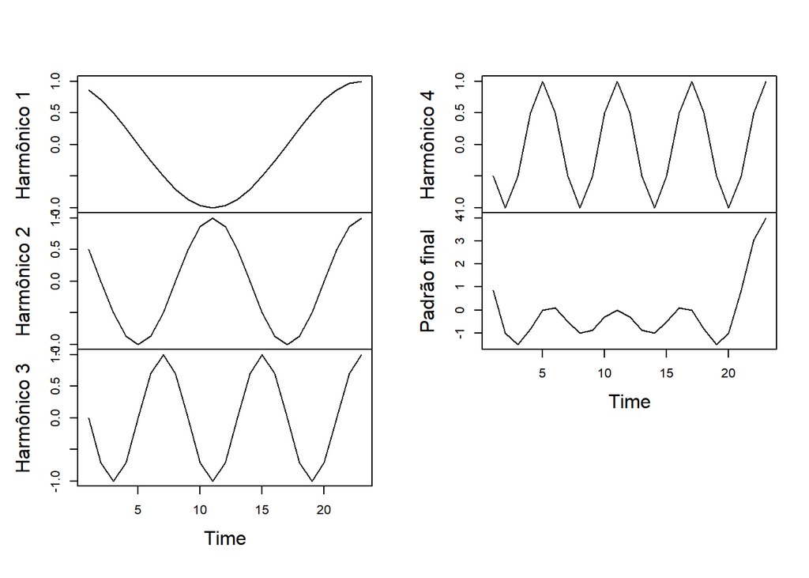

No caso geral, para um período $p$, podemos converter o modelo acima em um modelo linear

$$g(t)=\sum_{j=1}^{q}
\beta_{1,j}\cos\left(\frac{2\pi}{p}jt\right)+\beta_{2,j}\sin\left(\frac{2\pi}{p}jt\right).$$
De fato, existe $\boldsymbol{F}_t'$ tal que

$$g(t)=\boldsymbol{F}_t'\boldsymbol{\beta},$$
onde $\boldsymbol{\beta}$ é um vetor contendo $\beta_{1,1},\beta_{1,2},\ldots,\beta_{1,q},\beta_{2,q}$. O modelo

$$y_t=
\boldsymbol{F}_t'\boldsymbol{\beta}+\varepsilon_t$$
é denominado regressão harmônica. Assumindo que o vetor de parâmetros pode evoluir no tempo $t$, considerando uma estrutura de nível, teremos o modelo de regressão harmônica dinâmico.

Vamos analisar a série `dnottem` utilizando esse modelo com apenas um harmônico. A função `dlmModTrig(p,q)` cria as matrizes necessárias para o modelo de regressão harmônica com período $p$ e $q$ harmônicos (se omitido, serão utilizados $p/2$ harmônicos).

```r
mod <- dlmModTrig(12, 1)
mod <- modFim( dnottem, mod)
```

Vamos aplicar o filtro de Kalman:

```r
filtro <- dlmFilter(dnottem,mod)
```

A previsão é semelhante ao que já fizemos, então vamos apenas analisar os erros de previsão.

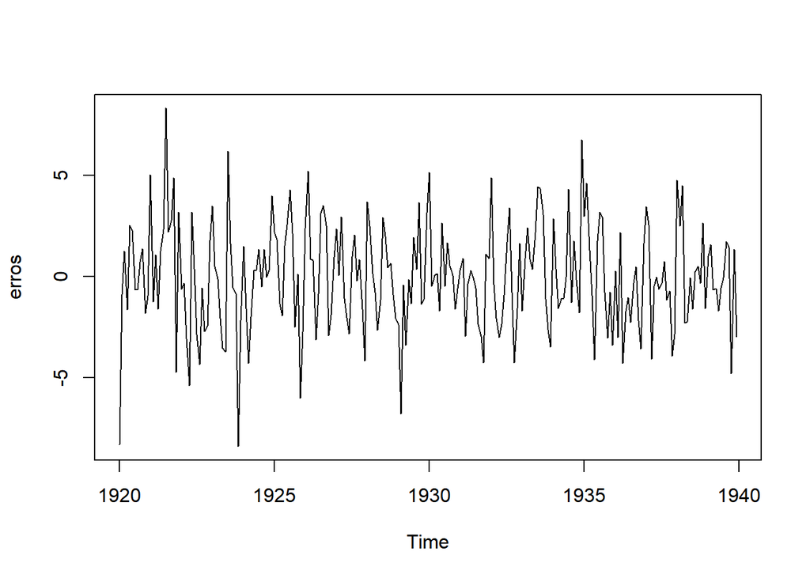

```r
erros <- dnottem - filtro$f
ts.plot(erros)
```

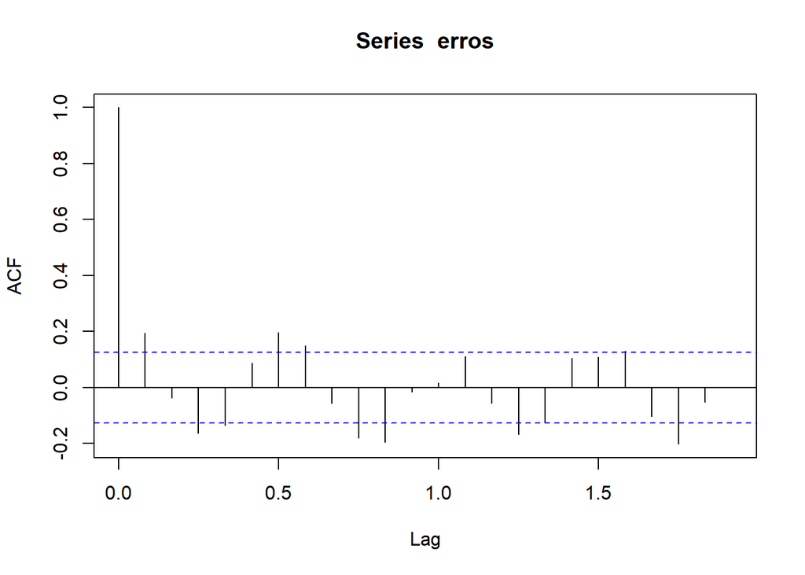

```r
acf(erros)
```

Note que o padrão sazonal não foi todo explicado. Abaixo utilizamos a função periodograma nos erros de previsão.

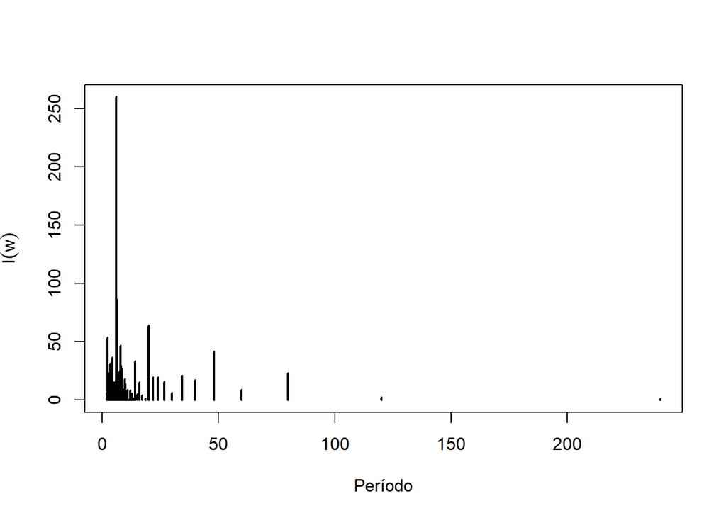

```
## Período:  6
```

```r
periodograma(erros)
```

Note que o período encontrado é 6 - isso corresponde ao harmônico 2, uma vez que 12/2=6. Vamos reescrever nosso modelo colocando os dois primeiros harmônicos.

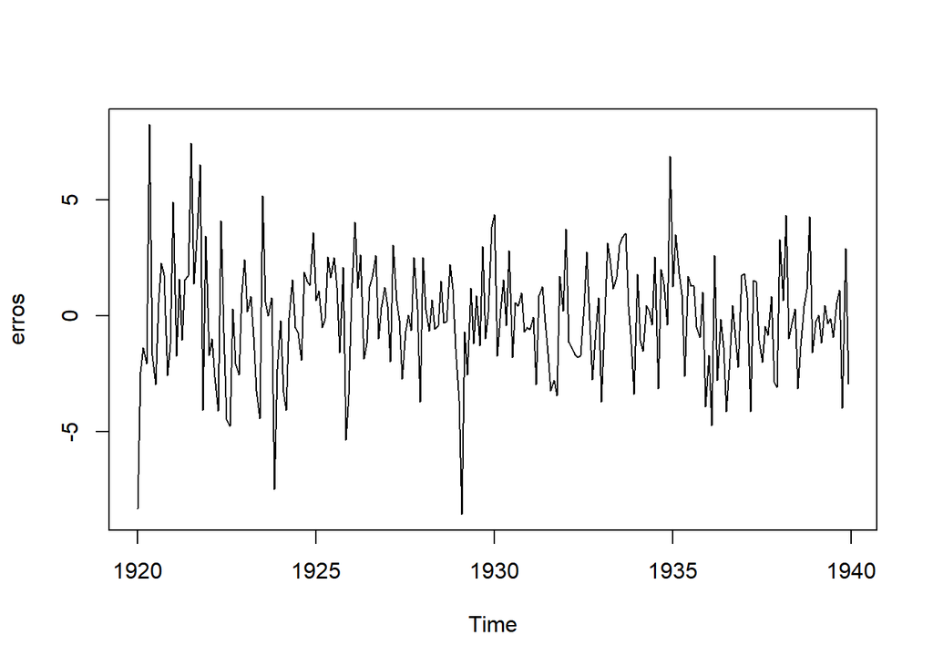

```r
mod <- dlmModTrig(12, 2)
mod <- modFim( dnottem, mod)
filtro <- dlmFilter(dnottem,mod)
erros <- dnottem - filtro$f
ts.plot(erros)
```

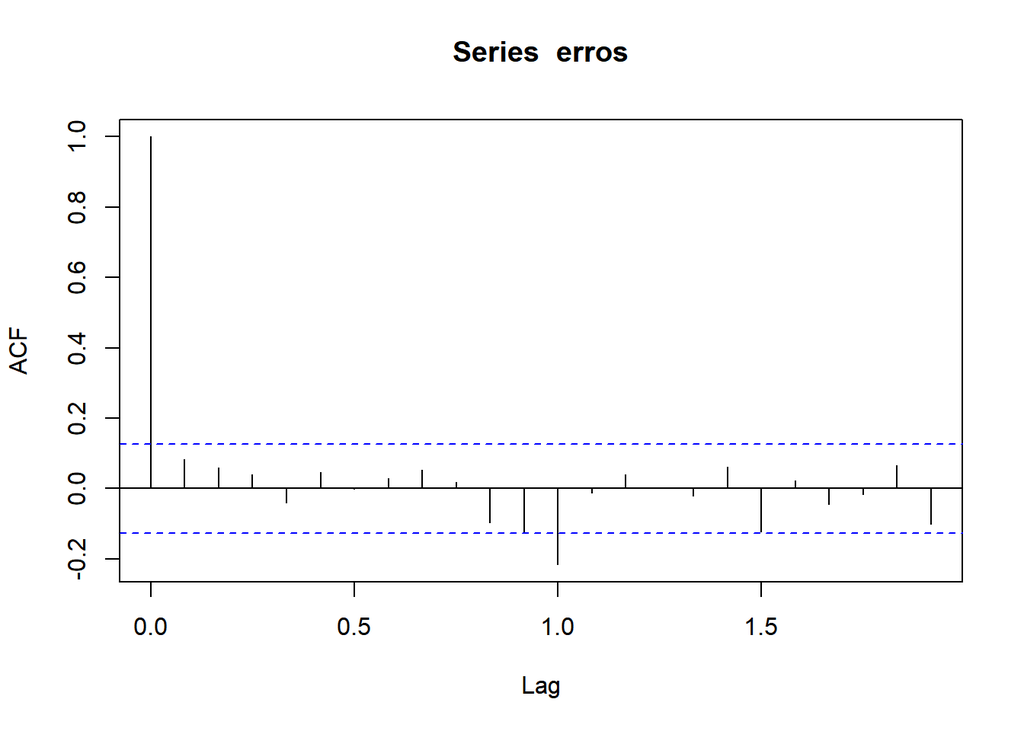

```r
acf(erros)
```

A amplitude é sem dúvidas uma medida importante, uma vez que ela mede a magnitude do harmônico. Vamos obter as estimativas suavizadas das duas amplitudes.

```r
suave <- dlmSmooth(filtro)
```

Em `suave$s`, obtemos as estimativas suavizadas para os estados da regressão harmônica. São quatro colunas, sendo que as duas primeiras são referentes ao harmônico 1 e as duas seguinda ao 2. Vamos recuperar as amplitudes:

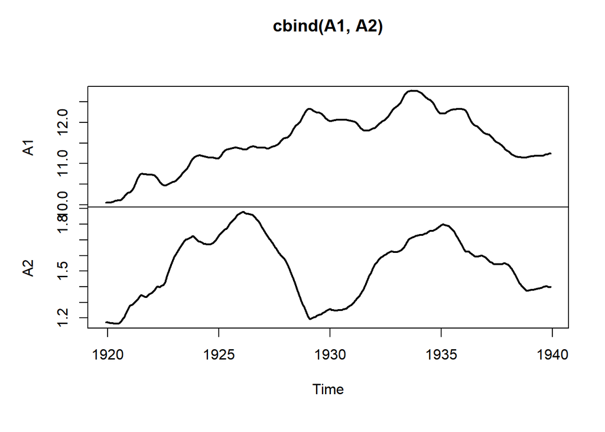

```r
A1 <- sqrt( suave$s[,1]^2 + suave$s[,2]^2 )
A2 <- sqrt( suave$s[,3]^2 + suave$s[,4]^2 )

plot.ts( cbind(A1, A2), lwd = 2)
```

[output not shown]